# siddhu (1)

```python
from google.colab import drive
drive.mount('/content/drive')
```

```python
!unzip /content/drive/MyDrive/dogs-vs-cats.zip
```

```
Archive:  /content/drive/MyDrive/dogs-vs-cats.zip
  inflating: sampleSubmission.csv
  inflating: test1.zip
  inflating: train.zip
```

```python
!unzip /content/train.zip
```

[output not shown]

[output cut: 4946 more lines]

[output not shown]

```python
!unzip /content/test1.zip
```

[output not shown]

[output cut: 4946 more lines]

[output not shown]

**Q1. Consider the Cats & Dogs example. Start initially with a training sample of 500, a validation sample of 250, and a test sample of 250 (like in the text). Use any technique to reduce overfitting and improve performance in developing a network that you train from scratch. What performance did you achieve?**

Copying images to training, validation, and test directories

```python
import os, shutil, pathlib

original_di = pathlib.Path("train")
newbase_di = pathlib.Path("cats_vs_dogs_small")

def make_subset(subset_name, start_index, end_index):
    for category in ("cat", "dog"):
        dir = newbase_di / subset_name / category
        os.makedirs(dir)
        fnames = [f"{category}.{i}.jpg" for i in range(start_index, end_index)]
        for fname in fnames:
            shutil.copyfile(src=original_di / fname,
                            dst=dir / fname)

make_subset("train", start_index=667, end_index=1167)
make_subset("validation", start_index=1168, end_index=1418)
make_subset("test", start_index=1419, end_index=1669)
```

Reading pictures with "image_dataset_from_directory"

```python
from tensorflow.keras.utils import image_dataset_from_directory

training_df = image_dataset_from_directory(
    newbase_di / "train",
    image_size=(180, 180),
    batch_size=32)
valid_df= image_dataset_from_directory(
    newbase_di / "validation",
    image_size=(180, 180),
    batch_size=32)
testing_df= image_dataset_from_directory(
    newbase_di / "test",
    image_size=(180, 180),
    batch_size=32)
```

```
Found 1000 files belonging to 2 classes.
Found 500 files belonging to 2 classes.
Found 500 files belonging to 2 classes.
```

Construct a dataset instance using a NumPy array containing 500 random samples, with each sample having a vector size of 16

```python
import numpy as np
import tensorflow as tf
random_no = np.random.normal(size=(500, 16))
data = tf.data.Dataset.from_tensor_slices(random_no)
```

```python
for i, element in enumerate(data):
    print(element.shape)
    if i >= 2:
        break
```

```
(16,)
(16,)
(16,)
```

```python
batch_d = data.batch(32)
for i, element in enumerate(batch_d):
    print(element.shape)
    if i >= 2:
        break
```

```
(32, 16)
(32, 16)
(32, 16)
```

```python
reshape_d = data.map(lambda x: tf.reshape(x, (4, 4)))
for i, element in enumerate(reshape_d):
    print(element.shape)
    if i >= 2:
        break
```

```
(4, 4)
(4, 4)
(4, 4)
```

Developing the model

Creating a tiny network for categorizing dogs versus cats

```python
for data_batch, labels_batch in training_df:
    print("data batch shape:", data_batch.shape)
    print("labels batch shape:", labels_batch.shape)
    break
```

```
data batch shape: (32, 180, 180, 3)
labels batch shape: (32,)
```

```python
from tensorflow import keras
from tensorflow.keras import layers

input = keras.Input(shape=(180, 180, 3))
si = layers.Rescaling(1./255)(input)
si = layers.Conv2D(filters=32, kernel_size=3, activation="relu")(si)
si = layers.MaxPooling2D(pool_size=2)(si)
si = layers.Conv2D(filters=64, kernel_size=3, activation="relu")(si)
si = layers.MaxPooling2D(pool_size=2)(si)
si = layers.Conv2D(filters=128, kernel_size=3, activation="relu")(si)
si = layers.MaxPooling2D(pool_size=2)(si)
si = layers.Conv2D(filters=256, kernel_size=3, activation="relu")(si)
si = layers.MaxPooling2D(pool_size=2)(si)
si = layers.Conv2D(filters=256, kernel_size=3, activation="relu")(si)
si = layers.Flatten()(si)
si = layers.Dropout(0.5)(si)
output = layers.Dense(1, activation="sigmoid")(si)
model = keras.Model(inputs=input, outputs=output)
```

preparing model for training

```python
model.compile(loss="binary_crossentropy",
              optimizer="adam",
              metrics=["accuracy"])
```

We first build the model, then use the training dataset to train it. At the conclusion of each epoch, we validate the model's performance using the validation dataset. In order to shorten the execution time of each epoch, I'm using GPU.

```python
model.summary()
```

```
Model: "functional"
```

```
┏━━━━━━━━━━━━━━━━━━━━━━━━━━━━━━━━━━━━━━┳━━━━━━━━━━━━━━━━━━━━━━━━━━━━━┳━━━━━━━━━━━━━━━━━┓
┃ Layer (type)                         ┃ Output Shape                ┃         Param # ┃
┡━━━━━━━━━━━━━━━━━━━━━━━━━━━━━━━━━━━━━━╇━━━━━━━━━━━━━━━━━━━━━━━━━━━━━╇━━━━━━━━━━━━━━━━━┩
│ input_layer (InputLayer)             │ (None, 180, 180, 3)         │               0 │
├──────────────────────────────────────┼─────────────────────────────┼─────────────────┤
│ rescaling (Rescaling)                │ (None, 180, 180, 3)         │               0 │
├──────────────────────────────────────┼─────────────────────────────┼─────────────────┤
│ conv2d (Conv2D)                      │ (None, 178, 178, 32)        │             896 │
├──────────────────────────────────────┼─────────────────────────────┼─────────────────┤
│ max_pooling2d (MaxPooling2D)         │ (None, 89, 89, 32)          │               0 │
├──────────────────────────────────────┼─────────────────────────────┼─────────────────┤
│ conv2d_1 (Conv2D)                    │ (None, 87, 87, 64)          │          18,496 │
├──────────────────────────────────────┼─────────────────────────────┼─────────────────┤
│ max_pooling2d_1 (MaxPooling2D)       │ (None, 43, 43, 64)          │               0 │
├──────────────────────────────────────┼─────────────────────────────┼─────────────────┤
│ conv2d_2 (Conv2D)                    │ (None, 41, 41, 128)         │          73,856 │
├──────────────────────────────────────┼─────────────────────────────┼─────────────────┤
│ max_pooling2d_2 (MaxPooling2D)       │ (None, 20, 20, 128)         │               0 │
├──────────────────────────────────────┼─────────────────────────────┼─────────────────┤
│ conv2d_3 (Conv2D)                    │ (None, 18, 18, 256)         │         295,168 │
├──────────────────────────────────────┼─────────────────────────────┼─────────────────┤
│ max_pooling2d_3 (MaxPooling2D)       │ (None, 9, 9, 256)           │               0 │
├──────────────────────────────────────┼─────────────────────────────┼─────────────────┤
│ conv2d_4 (Conv2D)                    │ (None, 7, 7, 256)           │         590,080 │
├──────────────────────────────────────┼─────────────────────────────┼─────────────────┤
│ flatten (Flatten)                    │ (None, 12544)               │               0 │
├──────────────────────────────────────┼─────────────────────────────┼─────────────────┤
│ dropout (Dropout)                    │ (None, 12544)               │               0 │
├──────────────────────────────────────┼─────────────────────────────┼─────────────────┤
│ dense (Dense)                        │ (None, 1)                   │          12,545 │
└──────────────────────────────────────┴─────────────────────────────┴─────────────────┘
```

```
 Total params: 991,041 (3.78 MB)
```

```
 Trainable params: 991,041 (3.78 MB)
```

```
 Non-trainable params: 0 (0.00 B)
```

Dataset is used for model fitting

```python
from keras.callbacks import ModelCheckpoint, EarlyStopping

callback = [
    keras.callbacks.ModelCheckpoint(
        filepath="convnet_from_scratch.keras",
        save_best_only=True,
        monitor="val_loss")
]
history = model.fit(
    training_df,
    epochs=10,
    validation_data=valid_df,
    callbacks=callback)
```

```
32/32 ━━━━━━━━━━━━━━━━━━━━ 18s 256ms/step - accuracy: 0.4926 - loss: 0.7040 - val_accuracy: 0.5000 - val_loss: 0.6932
32/32 ━━━━━━━━━━━━━━━━━━━━ 2s 55ms/step - accuracy: 0.4939 - loss: 0.6933 - val_accuracy: 0.6140 - val_loss: 0.6924
32/32 ━━━━━━━━━━━━━━━━━━━━ 2s 55ms/step - accuracy: 0.5176 - loss: 0.6921 - val_accuracy: 0.5760 - val_loss: 0.6869
32/32 ━━━━━━━━━━━━━━━━━━━━ 2s 76ms/step - accuracy: 0.5256 - loss: 0.6899 - val_accuracy: 0.6300 - val_loss: 0.6622
32/32 ━━━━━━━━━━━━━━━━━━━━ 3s 106ms/step - accuracy: 0.6119 - loss: 0.6652 - val_accuracy: 0.6300 - val_loss: 0.6384
32/32 ━━━━━━━━━━━━━━━━━━━━ 3s 92ms/step - accuracy: 0.6097 - loss: 0.6488 - val_accuracy: 0.6500 - val_loss: 0.6378
32/32 ━━━━━━━━━━━━━━━━━━━━ 4s 57ms/step - accuracy: 0.6615 - loss: 0.6228 - val_accuracy: 0.6360 - val_loss: 0.6259
32/32 ━━━━━━━━━━━━━━━━━━━━ 2s 55ms/step - accuracy: 0.6691 - loss: 0.6002 - val_accuracy: 0.6720 - val_loss: 0.5973
32/32 ━━━━━━━━━━━━━━━━━━━━ 2s 57ms/step - accuracy: 0.7033 - loss: 0.5736 - val_accuracy: 0.6680 - val_loss: 0.6076
32/32 ━━━━━━━━━━━━━━━━━━━━ 3s 78ms/step - accuracy: 0.7115 - loss: 0.5664 - val_accuracy: 0.6580 - val_loss: 0.6351
```

For better visualization and understanding the curves of loss and accuracy during training were constructed

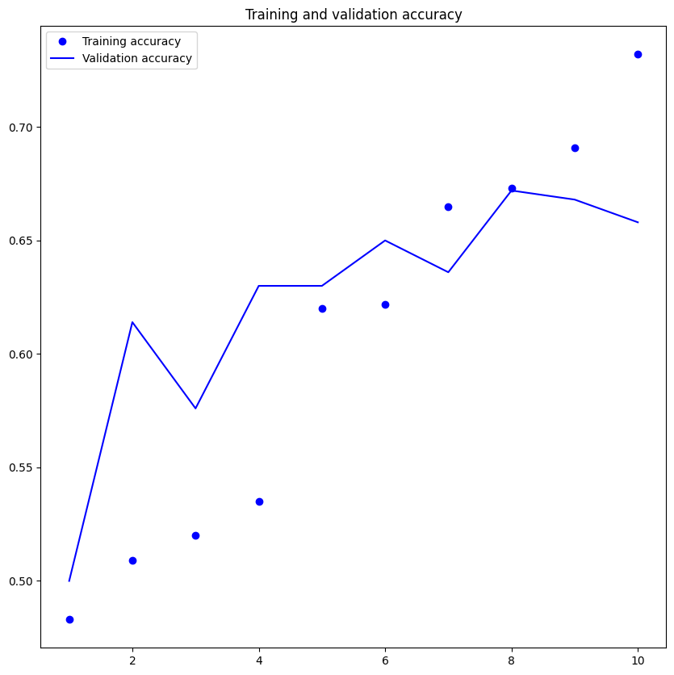

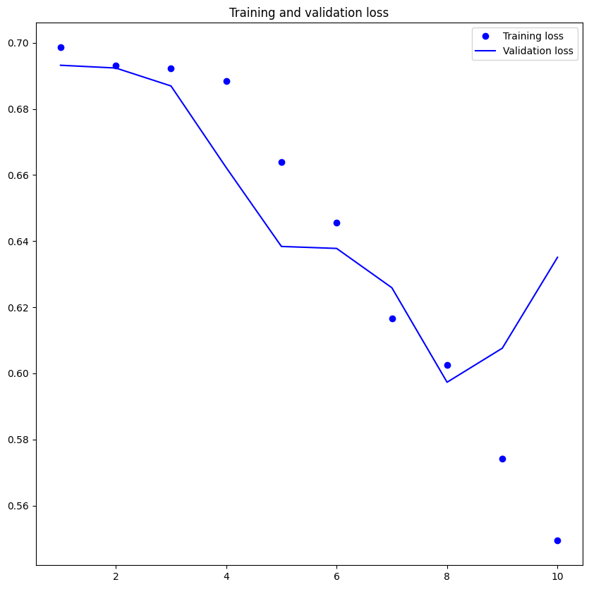

```python
import matplotlib.pyplot as plt

plt.figure(figsize=(10, 10))
acc = history.history["accuracy"]
val_acc = history.history["val_accuracy"]
loss = history.history["loss"]
val_loss = history.history["val_loss"]
epochs = range(1, len(acc) + 1)
plt.plot(epochs, acc, "bo", label="Training accuracy")
plt.plot(epochs, val_acc, "b", label="Validation accuracy")
plt.title("Training and validation accuracy")
plt.legend()
plt.figure()
plt.figure(figsize=(10, 10))
plt.plot(epochs, loss, "bo", label="Training loss")
plt.plot(epochs, val_loss, "b", label="Validation loss")
plt.title("Training and validation loss")
plt.legend()
plt.show()
```

```python
test_acc = keras.models.load_model("convnet_from_scratch.keras")
test_loss, test_acc = test_acc.evaluate(testing_df)
print(f"Test accuracy: {test_acc:.3f}")
```

```
16/16 ━━━━━━━━━━━━━━━━━━━━ 2s 65ms/step - accuracy: 0.6853 - loss: 0.6271
Test accuracy: 0.670
```

**Q2. Increase your training sample size. You may pick any amount. Keep the validation and test samples the same as above. Optimize your network (again training from scratch). What performance did you achieve?**

Using data augmentation

Define a data augmentation stage to add to an image model

```python
import os, shutil, pathlib

shutil.rmtree("./cats_vs_dogs_small_Q2", ignore_errors=True)

original_dir = pathlib.Path("train")
new_base_dir = pathlib.Path("cats_vs_dogs_small_Q2")

def make_subset(subset_name, start_index, end_index):
    for category in ("cat", "dog"):
        dir = new_base_dir / subset_name / category
        os.makedirs(dir)
        fnames = [f"{category}.{i}.jpg" for i in range(start_index, end_index)]
        for fname in fnames:
            shutil.copyfile(src=original_dir / fname,
                            dst=dir / fname)
#Creating training, Test and validation sets.
#Training has 1500 samples, test has 500 samples and validation has 500 samples.
make_subset("train", start_index=667, end_index=2167)
make_subset("validation", start_index=2168, end_index=2668)
make_subset("test", start_index=2669, end_index=3168)
```

```python
augmentation = keras.Sequential(
    [
        layers.RandomFlip("horizontal"),
        layers.RandomRotation(0.1),
        layers.RandomZoom(0.2),
    ]
)
```

showing the training augmented pictures

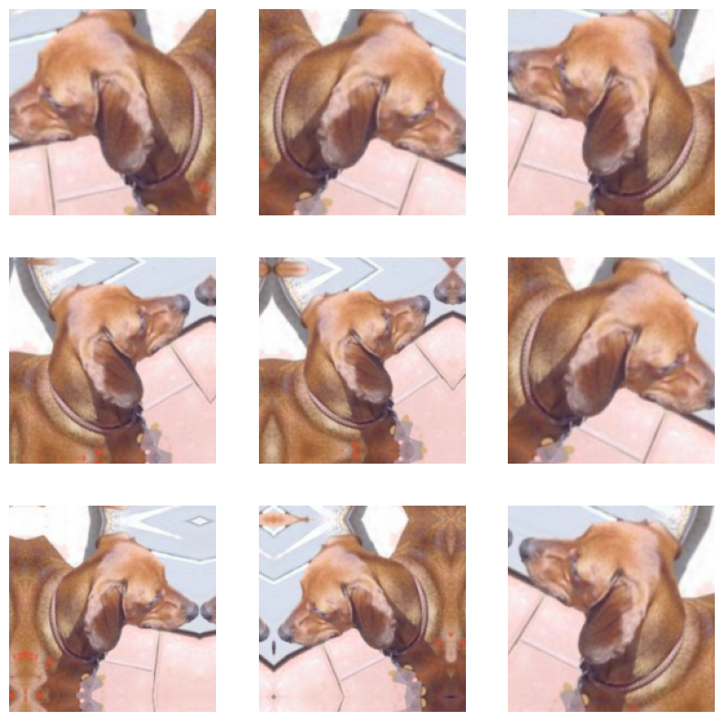

```python
plt.figure(figsize=(10, 10))
for images, _ in training_df.take(1):
    for i in range(9):
        augmented_pics = augmentation(images)
        ax = plt.subplot(3, 3, i + 1)
        plt.imshow(augmented_pics[0].numpy().astype("uint8"))
        plt.axis("off")
```

Creating a new convolutional neural network with dropout and picture augmentation

```python
in2 = keras.Input(shape=(180, 180, 3))
si2 = augmentation(in2)
si2 = layers.Rescaling(1./255)(si2)
si2 = layers.Conv2D(filters=32, kernel_size=3, activation="relu")(si2)
si2 = layers.MaxPooling2D(pool_size=2)(si2)
si2 = layers.Conv2D(filters=64, kernel_size=3, activation="relu")(si2)
si2 = layers.MaxPooling2D(pool_size=2)(si2)
si2 = layers.Conv2D(filters=128, kernel_size=3, activation="relu")(si2)
si2 = layers.MaxPooling2D(pool_size=2)(si2)
si2 = layers.Conv2D(filters=256, kernel_size=3, activation="relu")(si2)
si2 = layers.MaxPooling2D(pool_size=2)(si2)
si2 = layers.Conv2D(filters=256, kernel_size=3, activation="relu")(si2)
si2 = layers.Flatten()(si2)
si2 = layers.Dropout(0.5)(si2)
op2 = layers.Dense(1, activation="sigmoid")(si2)
model2 = keras.Model(inputs=in2, outputs=op2)

model2.compile(loss="binary_crossentropy",
              optimizer="adam",
              metrics=["accuracy"])
```

```python
from keras.callbacks import ModelCheckpoint, EarlyStopping
callback_2 = [
    keras.callbacks.ModelCheckpoint(
        filepath="convnet_from_scratch_with_augmentation.keras",
        save_best_only=True,
        monitor="val_loss")
]
history_2 = model2.fit(
    training_df,
    epochs=30,
    validation_data=valid_df,
    callbacks=callback_2)
```

```
32/32 ━━━━━━━━━━━━━━━━━━━━ 8s 88ms/step - accuracy: 0.5113 - loss: 0.7153 - val_accuracy: 0.5000 - val_loss: 0.6930
32/32 ━━━━━━━━━━━━━━━━━━━━ 8s 112ms/step - accuracy: 0.4942 - loss: 0.6933 - val_accuracy: 0.5000 - val_loss: 0.6926
32/32 ━━━━━━━━━━━━━━━━━━━━ 2s 59ms/step - accuracy: 0.5108 - loss: 0.6935 - val_accuracy: 0.6060 - val_loss: 0.6926
32/32 ━━━━━━━━━━━━━━━━━━━━ 2s 56ms/step - accuracy: 0.5170 - loss: 0.6928 - val_accuracy: 0.5000 - val_loss: 0.6936
32/32 ━━━━━━━━━━━━━━━━━━━━ 2s 57ms/step - accuracy: 0.4989 - loss: 0.6936 - val_accuracy: 0.5000 - val_loss: 0.6930
32/32 ━━━━━━━━━━━━━━━━━━━━ 2s 57ms/step - accuracy: 0.5147 - loss: 0.6931 - val_accuracy: 0.5000 - val_loss: 0.6930
32/32 ━━━━━━━━━━━━━━━━━━━━ 2s 62ms/step - accuracy: 0.4959 - loss: 0.6932 - val_accuracy: 0.5000 - val_loss: 0.6931
32/32 ━━━━━━━━━━━━━━━━━━━━ 3s 90ms/step - accuracy: 0.5037 - loss: 0.6933 - val_accuracy: 0.5000 - val_loss: 0.6906
32/32 ━━━━━━━━━━━━━━━━━━━━ 5s 73ms/step - accuracy: 0.5127 - loss: 0.6902 - val_accuracy: 0.5000 - val_loss: 0.6978
32/32 ━━━━━━━━━━━━━━━━━━━━ 2s 57ms/step - accuracy: 0.5119 - loss: 0.7032 - val_accuracy: 0.5000 - val_loss: 0.6925
32/32 ━━━━━━━━━━━━━━━━━━━━ 3s 56ms/step - accuracy: 0.5064 - loss: 0.6951 - val_accuracy: 0.5020 - val_loss: 0.6932
32/32 ━━━━━━━━━━━━━━━━━━━━ 2s 55ms/step - accuracy: 0.4772 - loss: 0.6936 - val_accuracy: 0.5020 - val_loss: 0.6931
32/32 ━━━━━━━━━━━━━━━━━━━━ 2s 56ms/step - accuracy: 0.5153 - loss: 0.6931 - val_accuracy: 0.5000 - val_loss: 0.6930
32/32 ━━━━━━━━━━━━━━━━━━━━ 3s 86ms/step - accuracy: 0.4941 - loss: 0.6932 - val_accuracy: 0.5060 - val_loss: 0.6928
32/32 ━━━━━━━━━━━━━━━━━━━━ 3s 109ms/step - accuracy: 0.5000 - loss: 0.6929 - val_accuracy: 0.6140 - val_loss: 0.6871
32/32 ━━━━━━━━━━━━━━━━━━━━ 3s 57ms/step - accuracy: 0.5784 - loss: 0.6903 - val_accuracy: 0.5000 - val_loss: 0.6937
32/32 ━━━━━━━━━━━━━━━━━━━━ 3s 57ms/step - accuracy: 0.5136 - loss: 0.6947 - val_accuracy: 0.5000 - val_loss: 0.6950
32/32 ━━━━━━━━━━━━━━━━━━━━ 2s 56ms/step - accuracy: 0.5094 - loss: 0.6921 - val_accuracy: 0.5080 - val_loss: 0.6907
32/32 ━━━━━━━━━━━━━━━━━━━━ 3s 60ms/step - accuracy: 0.4940 - loss: 0.6906 - val_accuracy: 0.5800 - val_loss: 0.6773
32/32 ━━━━━━━━━━━━━━━━━━━━ 2s 68ms/step - accuracy: 0.5192 - loss: 0.6873 - val_accuracy: 0.5200 - val_loss: 0.6925
32/32 ━━━━━━━━━━━━━━━━━━━━ 3s 89ms/step - accuracy: 0.4774 - loss: 0.6928 - val_accuracy: 0.5020 - val_loss: 0.6882
32/32 ━━━━━━━━━━━━━━━━━━━━ 4s 66ms/step - accuracy: 0.5009 - loss: 0.6891 - val_accuracy: 0.5440 - val_loss: 0.6858
32/32 ━━━━━━━━━━━━━━━━━━━━ 2s 56ms/step - accuracy: 0.5427 - loss: 0.6874 - val_accuracy: 0.5480 - val_loss: 0.6847
32/32 ━━━━━━━━━━━━━━━━━━━━ 3s 57ms/step - accuracy: 0.4768 - loss: 0.6931 - val_accuracy: 0.5000 - val_loss: 0.6930
32/32 ━━━━━━━━━━━━━━━━━━━━ 3s 57ms/step - accuracy: 0.5217 - loss: 0.6928 - val_accuracy: 0.5000 - val_loss: 0.6930
32/32 ━━━━━━━━━━━━━━━━━━━━ 2s 64ms/step - accuracy: 0.4993 - loss: 0.6927 - val_accuracy: 0.5020 - val_loss: 0.6877
32/32 ━━━━━━━━━━━━━━━━━━━━ 3s 89ms/step - accuracy: 0.4846 - loss: 0.6940 - val_accuracy: 0.5000 - val_loss: 0.6931
32/32 ━━━━━━━━━━━━━━━━━━━━ 5s 72ms/step - accuracy: 0.4849 - loss: 0.6932 - val_accuracy: 0.5000 - val_loss: 0.6932
32/32 ━━━━━━━━━━━━━━━━━━━━ 2s 57ms/step - accuracy: 0.5092 - loss: 0.6932 - val_accuracy: 0.5000 - val_loss: 0.6931
32/32 ━━━━━━━━━━━━━━━━━━━━ 3s 56ms/step - accuracy: 0.4729 - loss: 0.6933 - val_accuracy: 0.5000 - val_loss: 0.6931
```

model evaluated based on test set

```python
test_acc2 = keras.models.load_model(
    "convnet_from_scratch_with_augmentation.keras")
test_loss, test_acc = test_acc2.evaluate(testing_df)
print(f"Test accuracy: {test_acc:.3f}")
```

```
16/16 ━━━━━━━━━━━━━━━━━━━━ 1s 29ms/step - accuracy: 0.5756 - loss: 0.6877
Test accuracy: 0.580
```

**Q3. Now change your training sample so that you achieve better performance than those from Steps 1 and 2. This sample size may be larger, or smaller than those in the previous steps. The objective is to find the ideal training sample size to get best prediction results.**

When there are 1000 training samples, training accuracy improves.

```python
original_dir = pathlib.Path("train")
new_base_dir = pathlib.Path("cats_vs_dogs_small_Q3")

def make_subset(subset_name, start_index, end_index):
    for category in ("cat", "dog"):
        dir = new_base_dir / subset_name / category
        os.makedirs(dir)
        fnames = [f"{category}.{i}.jpg" for i in range(start_index, end_index)]
        for fname in fnames:
            shutil.copyfile(src=original_dir / fname,
                            dst=dir / fname)
#Creating training, Test and validation sets.
#Training has 2000 samples, test has 500 samples and validation has 500 samples.
make_subset("train", start_index=667, end_index=2667)
make_subset("validation", start_index=2668, end_index=3168)
make_subset("test", start_index=3169, end_index=3669)
```

```python
in3 = keras.Input(shape=(180, 180, 3))
si3 = augmentation(in3)
si3 = layers.Rescaling(1./255)(si3)
si3 = layers.Conv2D(filters=32, kernel_size=3, activation="relu")(si3)
si3 = layers.MaxPooling2D(pool_size=2)(si3)
si3 = layers.Conv2D(filters=64, kernel_size=3, activation="relu")(si3)
si3 = layers.MaxPooling2D(pool_size=2)(si3)
si3 = layers.Conv2D(filters=128, kernel_size=3, activation="relu")(si3)
si3 = layers.MaxPooling2D(pool_size=2)(si3)
si3 = layers.Conv2D(filters=256, kernel_size=3, activation="relu")(si3)
si3 = layers.MaxPooling2D(pool_size=2)(si3)
si3 = layers.Conv2D(filters=256, kernel_size=3, activation="relu")(si3)
si3 = layers.Flatten()(si3)
si3 = layers.Dropout(0.5)(si3)
op3 = layers.Dense(1, activation="sigmoid")(si3)
model3 = keras.Model(inputs=in3, outputs=op3)

model3.compile(loss="binary_crossentropy",
              optimizer="adam",
              metrics=["accuracy"])
```

```python
callback_3 = [
    keras.callbacks.ModelCheckpoint(
        filepath="convnet_from_scratch_with_augmentation1.keras",
        save_best_only=True,
        monitor="val_loss")
]
history_3 = model3.fit(
    training_df,
    epochs=50,
    validation_data=valid_df,
    callbacks=callback_3)
```

```
32/32 ━━━━━━━━━━━━━━━━━━━━ 6s 112ms/step - accuracy: 0.5137 - loss: 0.7001 - val_accuracy: 0.5000 - val_loss: 0.6923
32/32 ━━━━━━━━━━━━━━━━━━━━ 3s 100ms/step - accuracy: 0.5230 - loss: 0.6922 - val_accuracy: 0.5660 - val_loss: 0.6913
32/32 ━━━━━━━━━━━━━━━━━━━━ 3s 79ms/step - accuracy: 0.5508 - loss: 0.6914 - val_accuracy: 0.5900 - val_loss: 0.6845
32/32 ━━━━━━━━━━━━━━━━━━━━ 5s 61ms/step - accuracy: 0.5311 - loss: 0.6900 - val_accuracy: 0.5800 - val_loss: 0.6820
32/32 ━━━━━━━━━━━━━━━━━━━━ 2s 56ms/step - accuracy: 0.5694 - loss: 0.6808 - val_accuracy: 0.5100 - val_loss: 0.6857
32/32 ━━━━━━━━━━━━━━━━━━━━ 3s 59ms/step - accuracy: 0.5304 - loss: 0.6856 - val_accuracy: 0.6160 - val_loss: 0.6617
32/32 ━━━━━━━━━━━━━━━━━━━━ 3s 103ms/step - accuracy: 0.5650 - loss: 0.6706 - val_accuracy: 0.5220 - val_loss: 0.6845
32/32 ━━━━━━━━━━━━━━━━━━━━ 3s 91ms/step - accuracy: 0.5671 - loss: 0.6793 - val_accuracy: 0.5720 - val_loss: 0.6728
32/32 ━━━━━━━━━━━━━━━━━━━━ 3s 93ms/step - accuracy: 0.5992 - loss: 0.6661 - val_accuracy: 0.6140 - val_loss: 0.6610
32/32 ━━━━━━━━━━━━━━━━━━━━ 2s 55ms/step - accuracy: 0.5778 - loss: 0.6597 - val_accuracy: 0.5840 - val_loss: 0.6772
32/32 ━━━━━━━━━━━━━━━━━━━━ 2s 60ms/step - accuracy: 0.5669 - loss: 0.6757 - val_accuracy: 0.6320 - val_loss: 0.6494
32/32 ━━━━━━━━━━━━━━━━━━━━ 2s 59ms/step - accuracy: 0.5737 - loss: 0.6786 - val_accuracy: 0.6300 - val_loss: 0.6491
32/32 ━━━━━━━━━━━━━━━━━━━━ 3s 59ms/step - accuracy: 0.6115 - loss: 0.6556 - val_accuracy: 0.6580 - val_loss: 0.6321
32/32 ━━━━━━━━━━━━━━━━━━━━ 2s 70ms/step - accuracy: 0.6217 - loss: 0.6521 - val_accuracy: 0.6780 - val_loss: 0.6023
32/32 ━━━━━━━━━━━━━━━━━━━━ 3s 93ms/step - accuracy: 0.6417 - loss: 0.6384 - val_accuracy: 0.6980 - val_loss: 0.5919
32/32 ━━━━━━━━━━━━━━━━━━━━ 3s 95ms/step - accuracy: 0.6551 - loss: 0.6310 - val_accuracy: 0.6960 - val_loss: 0.5921
32/32 ━━━━━━━━━━━━━━━━━━━━ 4s 56ms/step - accuracy: 0.6767 - loss: 0.6019 - val_accuracy: 0.5680 - val_loss: 0.7554
32/32 ━━━━━━━━━━━━━━━━━━━━ 2s 56ms/step - accuracy: 0.6334 - loss: 0.6429 - val_accuracy: 0.6580 - val_loss: 0.6261
32/32 ━━━━━━━━━━━━━━━━━━━━ 3s 59ms/step - accuracy: 0.6744 - loss: 0.6013 - val_accuracy: 0.7020 - val_loss: 0.5659
32/32 ━━━━━━━━━━━━━━━━━━━━ 3s 59ms/step - accuracy: 0.6844 - loss: 0.5808 - val_accuracy: 0.6540 - val_loss: 0.6510
32/32 ━━━━━━━━━━━━━━━━━━━━ 3s 108ms/step - accuracy: 0.6542 - loss: 0.6052 - val_accuracy: 0.7180 - val_loss: 0.5804
32/32 ━━━━━━━━━━━━━━━━━━━━ 4s 119ms/step - accuracy: 0.7068 - loss: 0.5798 - val_accuracy: 0.7200 - val_loss: 0.5587
32/32 ━━━━━━━━━━━━━━━━━━━━ 3s 59ms/step - accuracy: 0.7292 - loss: 0.5544 - val_accuracy: 0.7520 - val_loss: 0.5188
32/32 ━━━━━━━━━━━━━━━━━━━━ 2s 57ms/step - accuracy: 0.7281 - loss: 0.5350 - val_accuracy: 0.7440 - val_loss: 0.5263
32/32 ━━━━━━━━━━━━━━━━━━━━ 2s 57ms/step - accuracy: 0.7236 - loss: 0.5409 - val_accuracy: 0.7240 - val_loss: 0.5468
32/32 ━━━━━━━━━━━━━━━━━━━━ 3s 59ms/step - accuracy: 0.7142 - loss: 0.5724 - val_accuracy: 0.7600 - val_loss: 0.5110
32/32 ━━━━━━━━━━━━━━━━━━━━ 4s 91ms/step - accuracy: 0.7395 - loss: 0.5145 - val_accuracy: 0.7700 - val_loss: 0.4914
32/32 ━━━━━━━━━━━━━━━━━━━━ 5s 81ms/step - accuracy: 0.8009 - loss: 0.4617 - val_accuracy: 0.7660 - val_loss: 0.4985
32/32 ━━━━━━━━━━━━━━━━━━━━ 2s 61ms/step - accuracy: 0.7617 - loss: 0.4998 - val_accuracy: 0.7640 - val_loss: 0.4810
32/32 ━━━━━━━━━━━━━━━━━━━━ 2s 56ms/step - accuracy: 0.7669 - loss: 0.4756 - val_accuracy: 0.7740 - val_loss: 0.5184
32/32 ━━━━━━━━━━━━━━━━━━━━ 2s 57ms/step - accuracy: 0.7596 - loss: 0.4888 - val_accuracy: 0.7420 - val_loss: 0.5154
32/32 ━━━━━━━━━━━━━━━━━━━━ 3s 56ms/step - accuracy: 0.7785 - loss: 0.4815 - val_accuracy: 0.7380 - val_loss: 0.5520
32/32 ━━━━━━━━━━━━━━━━━━━━ 3s 99ms/step - accuracy: 0.7667 - loss: 0.4639 - val_accuracy: 0.7740 - val_loss: 0.4832
32/32 ━━━━━━━━━━━━━━━━━━━━ 5s 81ms/step - accuracy: 0.7828 - loss: 0.4399 - val_accuracy: 0.7580 - val_loss: 0.5439
32/32 ━━━━━━━━━━━━━━━━━━━━ 2s 57ms/step - accuracy: 0.8005 - loss: 0.4200 - val_accuracy: 0.7800 - val_loss: 0.4927
32/32 ━━━━━━━━━━━━━━━━━━━━ 3s 57ms/step - accuracy: 0.8026 - loss: 0.3997 - val_accuracy: 0.7680 - val_loss: 0.5501
32/32 ━━━━━━━━━━━━━━━━━━━━ 3s 57ms/step - accuracy: 0.7881 - loss: 0.4411 - val_accuracy: 0.7640 - val_loss: 0.4968
32/32 ━━━━━━━━━━━━━━━━━━━━ 2s 57ms/step - accuracy: 0.8135 - loss: 0.4242 - val_accuracy: 0.7820 - val_loss: 0.4922
32/32 ━━━━━━━━━━━━━━━━━━━━ 4s 94ms/step - accuracy: 0.8196 - loss: 0.4027 - val_accuracy: 0.7760 - val_loss: 0.4508
32/32 ━━━━━━━━━━━━━━━━━━━━ 5s 77ms/step - accuracy: 0.8238 - loss: 0.3861 - val_accuracy: 0.7760 - val_loss: 0.4993
32/32 ━━━━━━━━━━━━━━━━━━━━ 2s 57ms/step - accuracy: 0.8021 - loss: 0.3991 - val_accuracy: 0.7820 - val_loss: 0.4699
32/32 ━━━━━━━━━━━━━━━━━━━━ 2s 56ms/step - accuracy: 0.8261 - loss: 0.3733 - val_accuracy: 0.7880 - val_loss: 0.5216
32/32 ━━━━━━━━━━━━━━━━━━━━ 3s 56ms/step - accuracy: 0.8228 - loss: 0.4096 - val_accuracy: 0.7840 - val_loss: 0.4623
32/32 ━━━━━━━━━━━━━━━━━━━━ 2s 57ms/step - accuracy: 0.8288 - loss: 0.3688 - val_accuracy: 0.7920 - val_loss: 0.4751
32/32 ━━━━━━━━━━━━━━━━━━━━ 3s 85ms/step - accuracy: 0.8112 - loss: 0.3810 - val_accuracy: 0.7800 - val_loss: 0.4797
32/32 ━━━━━━━━━━━━━━━━━━━━ 3s 104ms/step - accuracy: 0.8520 - loss: 0.3359 - val_accuracy: 0.7540 - val_loss: 0.5394
32/32 ━━━━━━━━━━━━━━━━━━━━ 3s 94ms/step - accuracy: 0.8404 - loss: 0.3626 - val_accuracy: 0.7840 - val_loss: 0.4812
32/32 ━━━━━━━━━━━━━━━━━━━━ 2s 57ms/step - accuracy: 0.8630 - loss: 0.3370 - val_accuracy: 0.7900 - val_loss: 0.4817
32/32 ━━━━━━━━━━━━━━━━━━━━ 2s 57ms/step - accuracy: 0.8495 - loss: 0.3305 - val_accuracy: 0.7840 - val_loss: 0.5467
32/32 ━━━━━━━━━━━━━━━━━━━━ 2s 57ms/step - accuracy: 0.8570 - loss: 0.3339 - val_accuracy: 0.7700 - val_loss: 0.6160
```

```python
acc_testing3 = keras.models.load_model(
    "convnet_from_scratch_with_augmentation1.keras")
test_loss, test_acc = acc_testing3.evaluate(testing_df)
print(f"Test accuracy: {test_acc:.3f}")
```

```
16/16 ━━━━━━━━━━━━━━━━━━━━ 1s 29ms/step - accuracy: 0.7532 - loss: 0.5124
Test accuracy: 0.736
```

**Q4. Repeat Steps 1-3, but now using a pretrained network. The sample sizes you use in Steps 2 and 3 for the pretrained network may be the same or different from those using the network where you trained from scratch. Again, use any and all optimization techniques to get best performance.**

Instantiating the VGG16 convolutional base

```python
convolution_base = keras.applications.vgg16.VGG16(
    weights="imagenet",
    include_top=False,
    input_shape=(180, 180, 3))
```

```
Downloading data from https://storage.googleapis.com/tensorflow/keras-applications/vgg16/vgg16_weights_tf_dim_ordering_tf_kernels_notop.h5
58889256/58889256 ━━━━━━━━━━━━━━━━━━━━ 0s 0us/step
```

```python
convolution_base.summary()
```

```
Model: "vgg16"
```

```
┏━━━━━━━━━━━━━━━━━━━━━━━━━━━━━━━━━━━━━━┳━━━━━━━━━━━━━━━━━━━━━━━━━━━━━┳━━━━━━━━━━━━━━━━━┓
┃ Layer (type)                         ┃ Output Shape                ┃         Param # ┃
┡━━━━━━━━━━━━━━━━━━━━━━━━━━━━━━━━━━━━━━╇━━━━━━━━━━━━━━━━━━━━━━━━━━━━━╇━━━━━━━━━━━━━━━━━┩
│ input_layer_4 (InputLayer)           │ (None, 180, 180, 3)         │               0 │
├──────────────────────────────────────┼─────────────────────────────┼─────────────────┤
│ block1_conv1 (Conv2D)                │ (None, 180, 180, 64)        │           1,792 │
├──────────────────────────────────────┼─────────────────────────────┼─────────────────┤
│ block1_conv2 (Conv2D)                │ (None, 180, 180, 64)        │          36,928 │
├──────────────────────────────────────┼─────────────────────────────┼─────────────────┤
│ block1_pool (MaxPooling2D)           │ (None, 90, 90, 64)          │               0 │
├──────────────────────────────────────┼─────────────────────────────┼─────────────────┤
│ block2_conv1 (Conv2D)                │ (None, 90, 90, 128)         │          73,856 │
├──────────────────────────────────────┼─────────────────────────────┼─────────────────┤
│ block2_conv2 (Conv2D)                │ (None, 90, 90, 128)         │         147,584 │
├──────────────────────────────────────┼─────────────────────────────┼─────────────────┤
│ block2_pool (MaxPooling2D)           │ (None, 45, 45, 128)         │               0 │
├──────────────────────────────────────┼─────────────────────────────┼─────────────────┤
│ block3_conv1 (Conv2D)                │ (None, 45, 45, 256)         │         295,168 │
├──────────────────────────────────────┼─────────────────────────────┼─────────────────┤
│ block3_conv2 (Conv2D)                │ (None, 45, 45, 256)         │         590,080 │
├──────────────────────────────────────┼─────────────────────────────┼─────────────────┤
│ block3_conv3 (Conv2D)                │ (None, 45, 45, 256)         │         590,080 │
├──────────────────────────────────────┼─────────────────────────────┼─────────────────┤
│ block3_pool (MaxPooling2D)           │ (None, 22, 22, 256)         │               0 │
├──────────────────────────────────────┼─────────────────────────────┼─────────────────┤
│ block4_conv1 (Conv2D)                │ (None, 22, 22, 512)         │       1,180,160 │
├──────────────────────────────────────┼─────────────────────────────┼─────────────────┤
│ block4_conv2 (Conv2D)                │ (None, 22, 22, 512)         │       2,359,808 │
├──────────────────────────────────────┼─────────────────────────────┼─────────────────┤
│ block4_conv3 (Conv2D)                │ (None, 22, 22, 512)         │       2,359,808 │
├──────────────────────────────────────┼─────────────────────────────┼─────────────────┤
│ block4_pool (MaxPooling2D)           │ (None, 11, 11, 512)         │               0 │
├──────────────────────────────────────┼─────────────────────────────┼─────────────────┤
│ block5_conv1 (Conv2D)                │ (None, 11, 11, 512)         │       2,359,808 │
├──────────────────────────────────────┼─────────────────────────────┼─────────────────┤
│ block5_conv2 (Conv2D)                │ (None, 11, 11, 512)         │       2,359,808 │
├──────────────────────────────────────┼─────────────────────────────┼─────────────────┤
│ block5_conv3 (Conv2D)                │ (None, 11, 11, 512)         │       2,359,808 │
├──────────────────────────────────────┼─────────────────────────────┼─────────────────┤
│ block5_pool (MaxPooling2D)           │ (None, 5, 5, 512)           │               0 │
└──────────────────────────────────────┴─────────────────────────────┴─────────────────┘
```

```
 Total params: 14,714,688 (56.13 MB)
```

```
 Trainable params: 14,714,688 (56.13 MB)
```

```
 Non-trainable params: 0 (0.00 B)
```

using a pretrained model for feature extraction without data augmentation

obtaining the labels that correlate with the VGG16 characteristics

```python
import numpy as np

def get_features_and_labels(dataset):
    all_feature = []
    all_label = []
    for images, labels in dataset:
        preprocessed_images = keras.applications.vgg16.preprocess_input(images)
        features = convolution_base.predict(preprocessed_images)
        all_feature.append(features)
        all_label.append(labels)
    return np.concatenate(all_feature), np.concatenate(all_label)

train_features, train_labels =  get_features_and_labels(training_df)
val_features, val_labels =  get_features_and_labels(valid_df)
test_features, test_labels =  get_features_and_labels(testing_df)
```

[output not shown]

[output cut: 9 more lines]

[output not shown]

```python
train_features.shape
```

```
(1000, 5, 5, 512)
```

```python
in6 = keras.Input(shape=(5, 5, 512))
si6 = layers.Flatten()(in6)
si6 = layers.Dense(256)(si6)
si6 = layers.Dropout(0.5)(si6)
output6 = layers.Dense(1, activation="sigmoid")(si6)
model6 = keras.Model(in6, output6)
model6.compile(loss="binary_crossentropy",
              optimizer="rmsprop",
              metrics=["accuracy"])

callback_6 = [
    keras.callbacks.ModelCheckpoint(
      filepath="feature_extraction.keras",
      save_best_only=True,
      monitor="val_loss")
]
history_6 = model6.fit(
    train_features, train_labels,
    epochs=20,
    validation_data=(val_features, val_labels),
    callbacks=callback_6)
```

```
32/32 ━━━━━━━━━━━━━━━━━━━━ 4s 61ms/step - accuracy: 0.8450 - loss: 76.7488 - val_accuracy: 0.9600 - val_loss: 3.3024
32/32 ━━━━━━━━━━━━━━━━━━━━ 0s 5ms/step - accuracy: 0.9750 - loss: 2.4051 - val_accuracy: 0.9600 - val_loss: 4.8522
32/32 ━━━━━━━━━━━━━━━━━━━━ 0s 4ms/step - accuracy: 0.9840 - loss: 1.2558 - val_accuracy: 0.9680 - val_loss: 4.7639
32/32 ━━━━━━━━━━━━━━━━━━━━ 0s 5ms/step - accuracy: 0.9965 - loss: 0.5350 - val_accuracy: 0.9580 - val_loss: 4.5901
32/32 ━━━━━━━━━━━━━━━━━━━━ 0s 4ms/step - accuracy: 0.9887 - loss: 1.0422 - val_accuracy: 0.9080 - val_loss: 23.2267
32/32 ━━━━━━━━━━━━━━━━━━━━ 0s 5ms/step - accuracy: 0.9930 - loss: 1.2360 - val_accuracy: 0.9620 - val_loss: 5.8365
32/32 ━━━━━━━━━━━━━━━━━━━━ 0s 5ms/step - accuracy: 0.9942 - loss: 0.5860 - val_accuracy: 0.9620 - val_loss: 11.1581
32/32 ━━━━━━━━━━━━━━━━━━━━ 0s 4ms/step - accuracy: 0.9914 - loss: 1.0437 - val_accuracy: 0.9660 - val_loss: 7.6755
32/32 ━━━━━━━━━━━━━━━━━━━━ 0s 7ms/step - accuracy: 0.9960 - loss: 0.4010 - val_accuracy: 0.9700 - val_loss: 7.0945
32/32 ━━━━━━━━━━━━━━━━━━━━ 0s 6ms/step - accuracy: 1.0000 - loss: 3.2168e-07 - val_accuracy: 0.9700 - val_loss: 7.0883
32/32 ━━━━━━━━━━━━━━━━━━━━ 0s 5ms/step - accuracy: 0.9981 - loss: 0.3103 - val_accuracy: 0.9600 - val_loss: 6.6895
32/32 ━━━━━━━━━━━━━━━━━━━━ 0s 6ms/step - accuracy: 0.9970 - loss: 0.1096 - val_accuracy: 0.9540 - val_loss: 7.7958
32/32 ━━━━━━━━━━━━━━━━━━━━ 0s 5ms/step - accuracy: 1.0000 - loss: 1.2168e-14 - val_accuracy: 0.9540 - val_loss: 7.7958
32/32 ━━━━━━━━━━━━━━━━━━━━ 0s 6ms/step - accuracy: 1.0000 - loss: 1.5061e-10 - val_accuracy: 0.9540 - val_loss: 7.7958
32/32 ━━━━━━━━━━━━━━━━━━━━ 0s 7ms/step - accuracy: 0.9996 - loss: 0.0456 - val_accuracy: 0.9680 - val_loss: 9.4223
32/32 ━━━━━━━━━━━━━━━━━━━━ 0s 6ms/step - accuracy: 0.9971 - loss: 0.1352 - val_accuracy: 0.9680 - val_loss: 7.0217
32/32 ━━━━━━━━━━━━━━━━━━━━ 0s 5ms/step - accuracy: 1.0000 - loss: 2.4467e-25 - val_accuracy: 0.9680 - val_loss: 7.0217
32/32 ━━━━━━━━━━━━━━━━━━━━ 0s 6ms/step - accuracy: 1.0000 - loss: 0.0000e+00 - val_accuracy: 0.9680 - val_loss: 7.0217
32/32 ━━━━━━━━━━━━━━━━━━━━ 0s 6ms/step - accuracy: 0.9969 - loss: 0.3016 - val_accuracy: 0.9520 - val_loss: 8.1208
32/32 ━━━━━━━━━━━━━━━━━━━━ 0s 6ms/step - accuracy: 0.9988 - loss: 0.0242 - val_accuracy: 0.9480 - val_loss: 8.4103
```

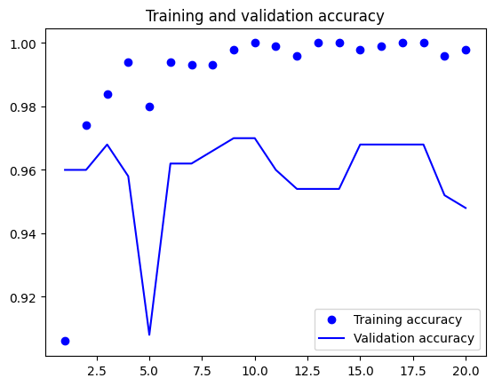

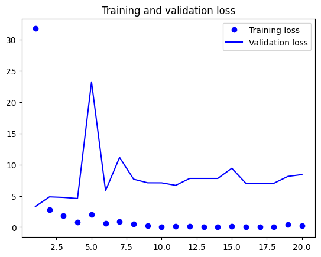

```python
import matplotlib.pyplot as plt
acc6 = history_6.history["accuracy"]
valacc6 = history_6.history["val_accuracy"]
loss6 = history_6.history["loss"]
valloss6 = history_6.history["val_loss"]
epochs = range(1, len(acc6) + 1)
plt.plot(epochs, acc6, "bo", label="Training accuracy")
plt.plot(epochs, valacc6, "b", label="Validation accuracy")
plt.title("Training and validation accuracy")
plt.legend()
plt.figure()
plt.plot(epochs, loss6, "bo", label="Training loss")
plt.plot(epochs, valloss6, "b", label="Validation loss")
plt.title("Training and validation loss")
plt.legend()
plt.show()
```

VGG16 convolutional base instantiation and freezing

```python
convolution_b  = keras.applications.vgg16.VGG16(
    weights="imagenet",
    include_top=False)
convolution_b.trainable = False

convolution_b.trainable = True
print("This is the number of trainable weights "
      "before freezing the conv base:", len(convolution_base.trainable_weights))

convolution_b.trainable = False
print("This is the number of trainable weights "
      "after freezing the conv base:", len(convolution_base.trainable_weights))
```

```
This is the number of trainable weights before freezing the conv base: 26
This is the number of trainable weights after freezing the conv base: 26
```

Model is now performing with a classifier and agumentation to convulation base

```python
augment2 = keras.Sequential(
    [
        layers.RandomFlip("horizontal"),
        layers.RandomRotation(0.1),
        layers.RandomZoom(0.2),
    ]
)

in72 = keras.Input(shape=(180, 180, 3))
si7 = augment2(in72)
si7 =keras.layers.Lambda(
     lambda x: keras.applications.vgg16.preprocess_input(x))(si7)
si7 = convolution_base(si7)
si7 = layers.Flatten()(si7)
si7 = layers.Dense(256)(si7)
si7 = layers.Dropout(0.5)(si7)
outputs = layers.Dense(1, activation="sigmoid")(si7)
model = keras.Model(in72, outputs)
model.compile(loss="binary_crossentropy",
              optimizer="rmsprop",
              metrics=["accuracy"])
```

```python
callbacks = [
    keras.callbacks.ModelCheckpoint(
        filepath="features_extraction_with_augmentation2.keras",
        save_best_only=True,
        monitor="val_loss"
    )
]

history = model.fit(
    training_df,
    epochs=10,
    validation_data=valid_df,
    callbacks=callbacks
)
```

```
32/32 ━━━━━━━━━━━━━━━━━━━━ 28s 530ms/step - accuracy: 0.5366 - loss: 604677.6250 - val_accuracy: 0.5000 - val_loss: 0.6926
32/32 ━━━━━━━━━━━━━━━━━━━━ 28s 345ms/step - accuracy: 0.5211 - loss: 0.6925 - val_accuracy: 0.5000 - val_loss: 0.6932
32/32 ━━━━━━━━━━━━━━━━━━━━ 20s 341ms/step - accuracy: 0.5131 - loss: 0.6939 - val_accuracy: 0.5000 - val_loss: 0.6932
32/32 ━━━━━━━━━━━━━━━━━━━━ 21s 370ms/step - accuracy: 0.5058 - loss: 0.6933 - val_accuracy: 0.5000 - val_loss: 0.6931
32/32 ━━━━━━━━━━━━━━━━━━━━ 20s 347ms/step - accuracy: 0.4797 - loss: 0.6936 - val_accuracy: 0.5000 - val_loss: 0.6932
32/32 ━━━━━━━━━━━━━━━━━━━━ 20s 342ms/step - accuracy: 0.4743 - loss: 0.6938 - val_accuracy: 0.5000 - val_loss: 0.6933
32/32 ━━━━━━━━━━━━━━━━━━━━ 20s 340ms/step - accuracy: 0.4873 - loss: 0.6935 - val_accuracy: 0.5000 - val_loss: 0.6932
32/32 ━━━━━━━━━━━━━━━━━━━━ 11s 345ms/step - accuracy: 0.5281 - loss: 0.6927 - val_accuracy: 0.5000 - val_loss: 0.6932
32/32 ━━━━━━━━━━━━━━━━━━━━ 20s 340ms/step - accuracy: 0.4687 - loss: 0.6937 - val_accuracy: 0.5000 - val_loss: 0.6932
32/32 ━━━━━━━━━━━━━━━━━━━━ 20s 340ms/step - accuracy: 0.5098 - loss: 0.6931 - val_accuracy: 0.5000 - val_loss: 0.6935
```

Fine-tuning a pretrained model

```python
convolution_b.trainable = True
for layer in convolution_b.layers[:-4]:
    layer.trainable = False
```

```python
inputs = keras.Input(shape=(180, 180, 3))
# Replace data_augmentation with augment2. augment2 is the sequential data augmentation layer defined earlier
x = augment2(inputs)
x = keras.applications.vgg16.preprocess_input(x)
x = convolution_base(x)
x = layers.Flatten()(x)
x = layers.Dense(256)(x)
x = layers.Dropout(0.5)(x)
outputs = layers.Dense(1, activation="sigmoid")(x)
model = keras.Model(inputs, outputs)
model.compile(loss="binary_crossentropy",
              optimizer="rmsprop",
              metrics=["accuracy"])

model.compile(loss="binary_crossentropy",
              optimizer=keras.optimizers.RMSprop(learning_rate=1e-5),
              metrics=["accuracy"])

callbacks = [
    keras.callbacks.ModelCheckpoint(
        filepath="fine_tuning.keras",
        save_best_only=True,
        monitor="val_loss")
]
history = model.fit(
    training_df,
    epochs=30,
    validation_data=valid_df,
    callbacks=callbacks)
```

```
32/32 ━━━━━━━━━━━━━━━━━━━━ 17s 319ms/step - accuracy: 0.5158 - loss: 0.6932 - val_accuracy: 0.5000 - val_loss: 0.6931
32/32 ━━━━━━━━━━━━━━━━━━━━ 8s 246ms/step - accuracy: 0.5099 - loss: 0.6931 - val_accuracy: 0.5000 - val_loss: 0.6931
32/32 ━━━━━━━━━━━━━━━━━━━━ 10s 231ms/step - accuracy: 0.5055 - loss: 0.6931 - val_accuracy: 0.5000 - val_loss: 0.6931
32/32 ━━━━━━━━━━━━━━━━━━━━ 6s 178ms/step - accuracy: 0.5132 - loss: 0.6932 - val_accuracy: 0.5000 - val_loss: 0.6931
32/32 ━━━━━━━━━━━━━━━━━━━━ 7s 211ms/step - accuracy: 0.4953 - loss: 0.6931 - val_accuracy: 0.5000 - val_loss: 0.6931
32/32 ━━━━━━━━━━━━━━━━━━━━ 9s 176ms/step - accuracy: 0.5034 - loss: 0.6931 - val_accuracy: 0.5000 - val_loss: 0.6931
32/32 ━━━━━━━━━━━━━━━━━━━━ 10s 179ms/step - accuracy: 0.4741 - loss: 0.6932 - val_accuracy: 0.5000 - val_loss: 0.6931
32/32 ━━━━━━━━━━━━━━━━━━━━ 6s 174ms/step - accuracy: 0.4890 - loss: 0.6932 - val_accuracy: 0.5000 - val_loss: 0.6931
32/32 ━━━━━━━━━━━━━━━━━━━━ 6s 181ms/step - accuracy: 0.4868 - loss: 0.6932 - val_accuracy: 0.5000 - val_loss: 0.6931
32/32 ━━━━━━━━━━━━━━━━━━━━ 6s 178ms/step - accuracy: 0.4767 - loss: 0.6932 - val_accuracy: 0.5000 - val_loss: 0.6931
32/32 ━━━━━━━━━━━━━━━━━━━━ 10s 176ms/step - accuracy: 0.5247 - loss: 0.6931 - val_accuracy: 0.5000 - val_loss: 0.6931
32/32 ━━━━━━━━━━━━━━━━━━━━ 10s 174ms/step - accuracy: 0.4855 - loss: 0.6932 - val_accuracy: 0.5000 - val_loss: 0.6931
32/32 ━━━━━━━━━━━━━━━━━━━━ 11s 188ms/step - accuracy: 0.4894 - loss: 0.6931 - val_accuracy: 0.5000 - val_loss: 0.6931
32/32 ━━━━━━━━━━━━━━━━━━━━ 10s 178ms/step - accuracy: 0.5325 - loss: 0.6931 - val_accuracy: 0.5000 - val_loss: 0.6931
32/32 ━━━━━━━━━━━━━━━━━━━━ 6s 202ms/step - accuracy: 0.5026 - loss: 0.6931 - val_accuracy: 0.5000 - val_loss: 0.6931
32/32 ━━━━━━━━━━━━━━━━━━━━ 9s 176ms/step - accuracy: 0.5139 - loss: 0.6931 - val_accuracy: 0.5000 - val_loss: 0.6931
32/32 ━━━━━━━━━━━━━━━━━━━━ 11s 205ms/step - accuracy: 0.4917 - loss: 0.6932 - val_accuracy: 0.5000 - val_loss: 0.6931
32/32 ━━━━━━━━━━━━━━━━━━━━ 6s 176ms/step - accuracy: 0.4922 - loss: 0.6932 - val_accuracy: 0.5000 - val_loss: 0.6931
32/32 ━━━━━━━━━━━━━━━━━━━━ 11s 204ms/step - accuracy: 0.4993 - loss: 0.6932 - val_accuracy: 0.5000 - val_loss: 0.6931
32/32 ━━━━━━━━━━━━━━━━━━━━ 10s 183ms/step - accuracy: 0.4844 - loss: 0.6931 - val_accuracy: 0.5000 - val_loss: 0.6931
32/32 ━━━━━━━━━━━━━━━━━━━━ 6s 174ms/step - accuracy: 0.5033 - loss: 0.6931 - val_accuracy: 0.5000 - val_loss: 0.6931
32/32 ━━━━━━━━━━━━━━━━━━━━ 10s 181ms/step - accuracy: 0.4898 - loss: 0.6932 - val_accuracy: 0.5000 - val_loss: 0.6931
32/32 ━━━━━━━━━━━━━━━━━━━━ 10s 174ms/step - accuracy: 0.5154 - loss: 0.6931 - val_accuracy: 0.5000 - val_loss: 0.6931
32/32 ━━━━━━━━━━━━━━━━━━━━ 10s 178ms/step - accuracy: 0.5051 - loss: 0.6931 - val_accuracy: 0.5000 - val_loss: 0.6931
32/32 ━━━━━━━━━━━━━━━━━━━━ 10s 181ms/step - accuracy: 0.4713 - loss: 0.6932 - val_accuracy: 0.5000 - val_loss: 0.6931
32/32 ━━━━━━━━━━━━━━━━━━━━ 6s 179ms/step - accuracy: 0.4834 - loss: 0.6932 - val_accuracy: 0.5000 - val_loss: 0.6931
32/32 ━━━━━━━━━━━━━━━━━━━━ 6s 176ms/step - accuracy: 0.4801 - loss: 0.6932 - val_accuracy: 0.5000 - val_loss: 0.6931
32/32 ━━━━━━━━━━━━━━━━━━━━ 7s 209ms/step - accuracy: 0.5098 - loss: 0.6932 - val_accuracy: 0.5000 - val_loss: 0.6931
32/32 ━━━━━━━━━━━━━━━━━━━━ 6s 178ms/step - accuracy: 0.5014 - loss: 0.6932 - val_accuracy: 0.5000 - val_loss: 0.6931
32/32 ━━━━━━━━━━━━━━━━━━━━ 10s 178ms/step - accuracy: 0.5025 - loss: 0.6931 - val_accuracy: 0.5000 - val_loss: 0.6931
```

```python
model = keras.models.load_model("fine_tuning.keras")
test_loss, test_acc = model.evaluate(testing_df)
print(f"Test accuracy: {test_acc:.4f}")
```

```
16/16 ━━━━━━━━━━━━━━━━━━━━ 2s 104ms/step - accuracy: 0.4921 - loss: 0.6931
Test accuracy: 0.5000
```